# UT comparison: T (WT) vs U (UBL5 knockout)

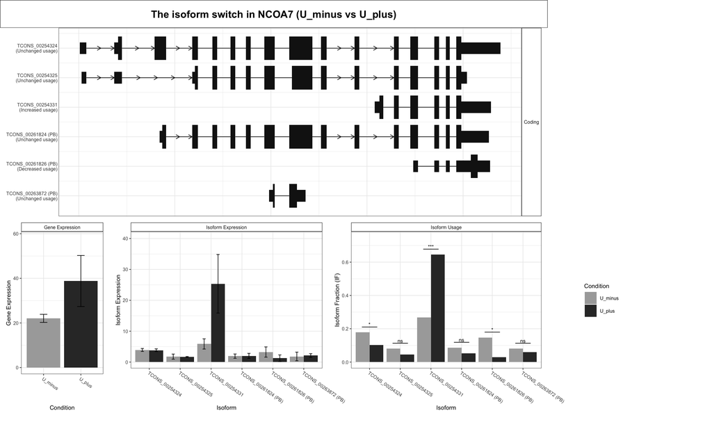

Showcase switchPlots for shared / T-only / U-only genes

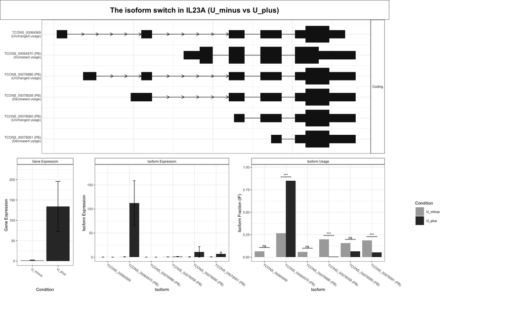

Showcase switchPlots for shared / T-only / U-only genes

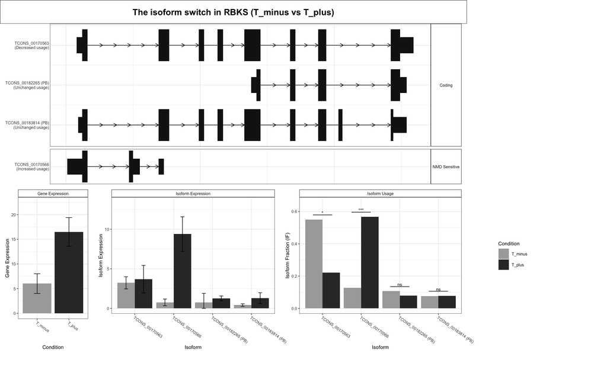

Showcase switchPlots for shared / T-only / U-only genes

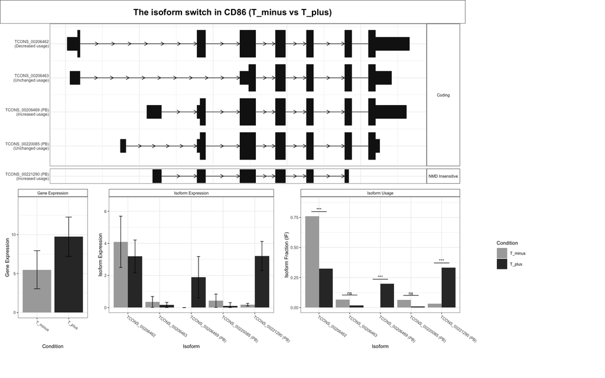

Showcase switchPlots for shared / T-only / U-only genes

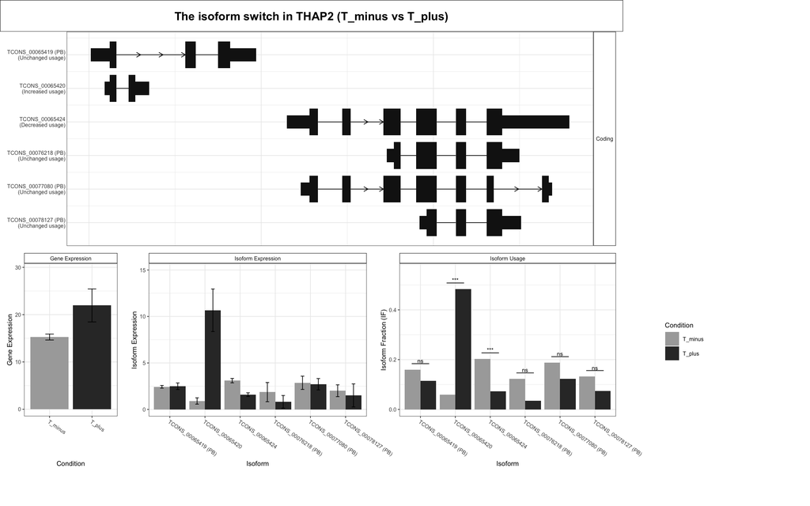

Showcase switchPlots for shared / T-only / U-only genes

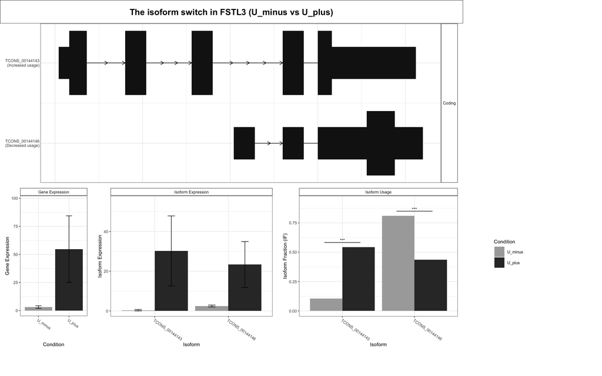

Showcase switchPlots for shared / T-only / U-only genes

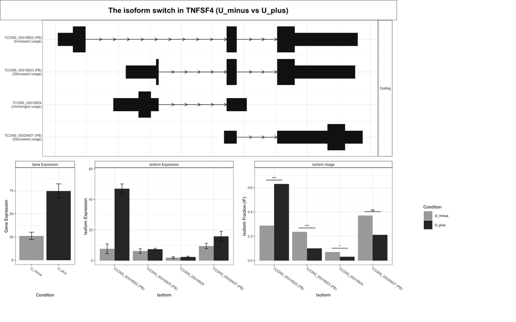

Showcase switchPlots for shared / T-only / U-only genes

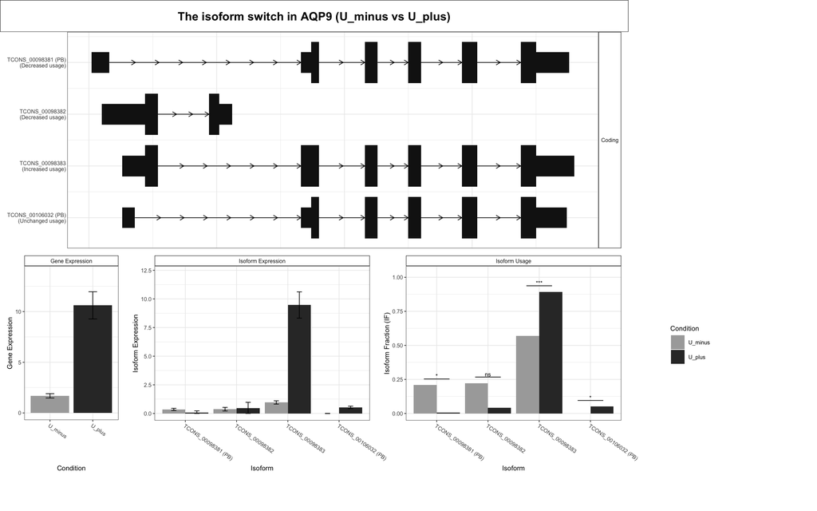

Showcase switchPlots for shared / T-only / U-only genes

| gene_name | overlap_class | dataset | figure |
| --- | --- | --- | --- |
| CCL22 | Shared (T and U) | T_UT | switch_T_Shared_T_and_U__01_CCL22.png |
| NCOA7 | Shared (T and U) | T_UT | switch_T_Shared_T_and_U__02_NCOA7.png |
| IL23A | Shared (T and U) | T_UT | switch_T_Shared_T_and_U__03_IL23A.png |
| CCL22 | Shared (T and U) | U_UT | switch_U_Shared_T_and_U__01_CCL22.png |
| NCOA7 | Shared (T and U) | U_UT | switch_U_Shared_T_and_U__02_NCOA7.png |
| IL23A | Shared (T and U) | U_UT | switch_U_Shared_T_and_U__03_IL23A.png |
| RBKS | T-only | T_UT | switch_T_T_only_07_RBKS.png |
| CD86 | T-only | T_UT | switch_T_T_only_08_CD86.png |
| THAP2 | T-only | T_UT | switch_T_T_only_09_THAP2.png |
| FSTL3 | U-only | U_UT | switch_U_U_only_14_FSTL3.png |
| TNFSF4 | U-only | U_UT | switch_U_U_only_15_TNFSF4.png |
| AQP9 | U-only | U_UT | switch_U_U_only_16_AQP9.png |

## 10 Methods notes

- Significance uses `config/config.yml` thresholds (`isoform_q`, `gene_q`, `min_abs_dif`).
- **Gene overlap** uses cleaned gene symbols (not `XLOC_*` / `ENSG*`), because those IDs are not stably shared across condition objects.
- **Isoform matching** uses `isoform_id` (`TCONS`) within the UT reference. Classification uses the unfiltered context tables, so *tested in the other genotype and not switching* is distinguished from *not detected there*. Without that context the labels fall back to *retained / not retained*, which only describes what survived the reduction.
- **The context layer is display and classification only.** Every significance call in this report comes from the primary (reduced) objects; the unfiltered tables contribute isoform fractions, replicate values, and presence/absence.
- **|dIF| by class** measures each isoform in exactly one dataset. It previously summarised the Shared class with `pmax(T, U)` against single values for T-only/U-only, which biased Shared upward by construction.
- Rebuild:

```bash
Rscript scripts/04_comparison_T_vs_U.R
quarto render reports/ut_t_vs_u_comparison.qmd
```